# Netflix_overview

### Project Title - Netflix Data Analaysis

### Import Libraries

```python
import pandas as pd
import matplotlib.pyplot as plt
import seaborn as sns
```

### Load Data

```python
df = pd.read_csv("netflix_titles.csv")
df.head()
```

|  | show_id | type | title | director | cast | country | date_added | release_year | rating | duration | listed_in | description |
| --- | --- | --- | --- | --- | --- | --- | --- | --- | --- | --- | --- | --- |
| 0 | s1 | Movie | Dick Johnson Is Dead | Kirsten Johnson | NaN | United States | September 25, 2021 | 2020 | PG-13 | 90 min | Documentaries | As her father nears the end of his life, filmm... |
| 1 | s2 | TV Show | Blood & Water | NaN | Ama Qamata, Khosi Ngema, Gail Mabalane, Thaban... | South Africa | September 24, 2021 | 2021 | TV-MA | 2 Seasons | International TV Shows, TV Dramas, TV Mysteries | After crossing paths at a party, a Cape Town t... |
| 2 | s3 | TV Show | Ganglands | Julien Leclercq | Sami Bouajila, Tracy Gotoas, Samuel Jouy, Nabi... | NaN | September 24, 2021 | 2021 | TV-MA | 1 Season | Crime TV Shows, International TV Shows, TV Act... | To protect his family from a powerful drug lor... |
| 3 | s4 | TV Show | Jailbirds New Orleans | NaN | NaN | NaN | September 24, 2021 | 2021 | TV-MA | 1 Season | Docuseries, Reality TV | Feuds, flirtations and toilet talk go down amo... |
| 4 | s5 | TV Show | Kota Factory | NaN | Mayur More, Jitendra Kumar, Ranjan Raj, Alam K... | India | September 24, 2021 | 2021 | TV-MA | 2 Seasons | International TV Shows, Romantic TV Shows, TV ... | In a city of coaching centers known to train I... |

### EDA - Expolatory Data Analaysis:

### Content Type Distribution (Movie vs TV Show):

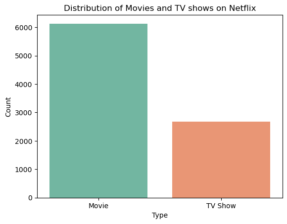

```python
sns.countplot(data=df, x='type', hue='type', palette='Set2', legend=False)
plt.title("Distribution of Movies and TV shows on Netflix")
plt.xlabel("Type")
plt.ylabel("Count")
plt.show()
```

**Interpretation** - Netflix's content library is primarily composed of movies, with a smaller portion being TV shows. This indicates a stronger focus on film content over episodic formats.

### Content Added to Netflix by Years:

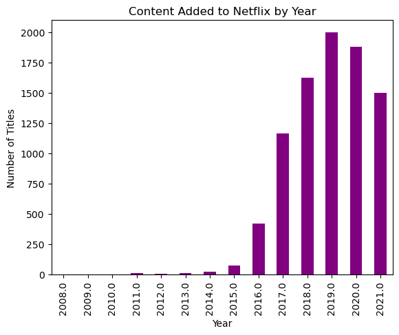

```python
df['date_added'] = pd.to_datetime(df['date_added'], errors='coerce')
df['year_added'] = df['date_added'].dt.year

df['year_added'].value_counts().sort_index().plot(kind='bar', color='purple')
plt.title("Content Added to Netflix by Year")
plt.xlabel("Year")
plt.ylabel("Number of Titles")
plt.show()
```

**Interpretation** - There is a significant increase in content additions from 2016 onwards, peaking in 2019. This reflects Netflix's aggressive expansion strategy during those years.

### Top 10 Countries with Most Content:

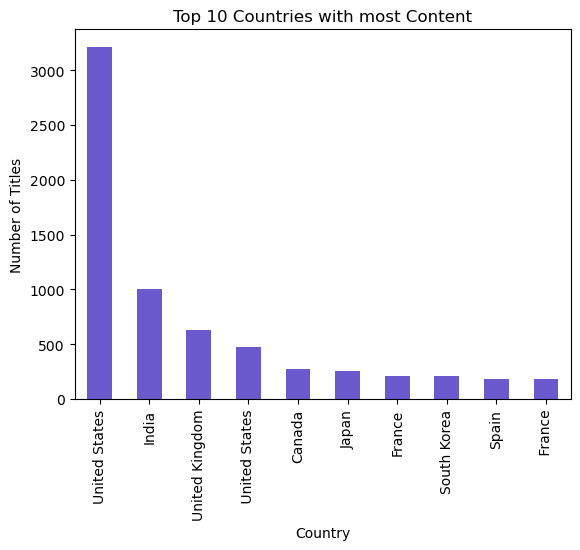

```python
top_countries = df['country'].dropna().str.split(',').explode().value_counts().head(10)
top_countries.plot(kind='bar', color='slateblue')
plt.title("Top 10 Countries with most Content")
plt.xlabel("Country")
plt.ylabel("Number of Titles")
plt.show()
```

**Interpretation** - The United States dominates Netflix's content production, followed by India and the United Kingdom. This shows Netflix's reliance on English-speaking countries with strong film/TV industries.

### Content Release Year by Type:

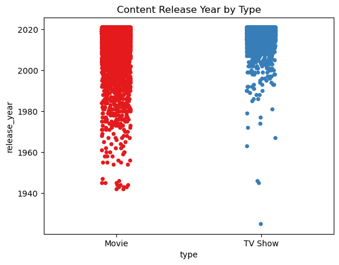

```python
sns.stripplot(data=df, x='type', hue='type', y='release_year', palette='Set1', jitter=True)
plt.title('Content Release Year by Type')
plt.show()
```

**Interpretation** - Both movies and TV shows are heavily clustered post-2000, with very little content released before 1980. This suggests a modern-focused catalog with recent content dominating the platform.

### Top 10 Directors by Number of Titles:

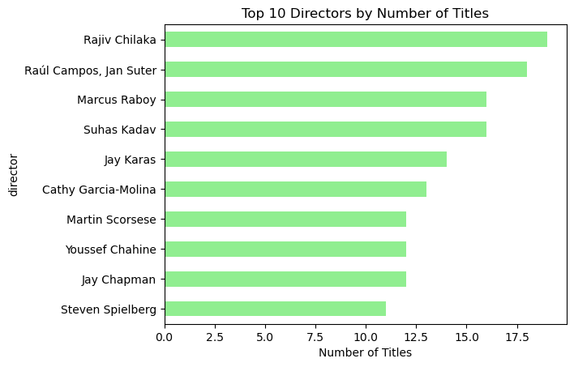

```python
top_directors = df['director'].value_counts().dropna().head(10)
top_directors.plot(kind='barh', color='lightgreen')
plt.title('Top 10 Directors by Number of Titles')
plt.xlabel('Number of Titles')
plt.gca().invert_yaxis()
plt.show()
```

**Interpretation** - Rajiv Chilaka leads the list, known for animation content. The presence of directors from different countries and genres reflects the diverse nature of Netflix's content portfolio.

### Distribution of Movie Durations (minutes):

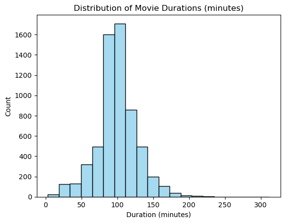

```python
movie_df = df[df['type'] == 'Movie'].copy()
movie_df['duration_int'] = movie_df['duration'].str.extract(r'(\d+)').astype(float)

sns.histplot(movie_df['duration_int'], bins=20, color='skyblue')
plt.title("Distribution of Movie Durations (minutes)")
plt.xlabel("Duration (minutes)")
plt.ylabel("Count")
plt.show()
```

**Interpretation** - Most movies on Netflix range from 80 to 120 minutes, which aligns with typical movie durations. Very few outliers go beyond 150, indicating a preference for standard-length films.

### Most Common Genres on Neflix:

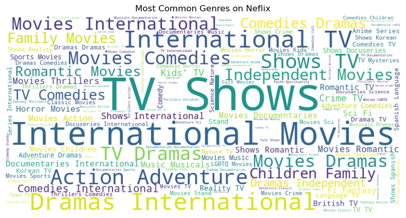

```python
from wordcloud import WordCloud
import matplotlib.pyplot as plt

text = ' '.join(df['listed_in'].dropna())
wordcloud = WordCloud(width=800, height=400, background_color='white').generate(text)

plt.figure(figsize=(10,5))
plt.imshow(wordcloud, interpolation='bilinear')
plt.axis('off')
plt.title('Most Common Genres on Neflix')
plt.show()
```

**Interpretation** - Genres like International, TV Shows, Dramas, Comedies and Action appear most frequently. This highlights Netflix's global and diverse content strategy.

### Top Ratings on Netflix:

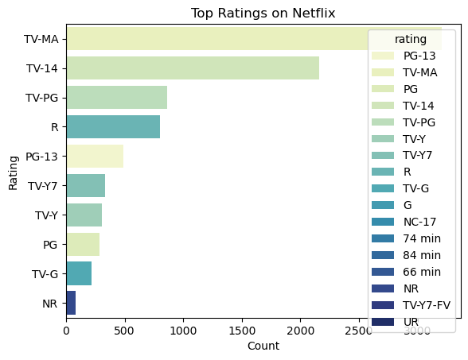

```python
sns.countplot(data=df, y='rating', hue='rating',  order=df['rating'].value_counts().index[:10], palette='YlGnBu')
plt.title("Top Ratings on Netflix")
plt.xlabel("Count")
plt.ylabel("Rating")
plt.show()
```

**Interpretation** - Most Netflix titles are rated TV-MA, followed by TV-14 AND TV-PG, showing a strong focus on content for mature and teen audiences.

### Content Count by Country and Year:

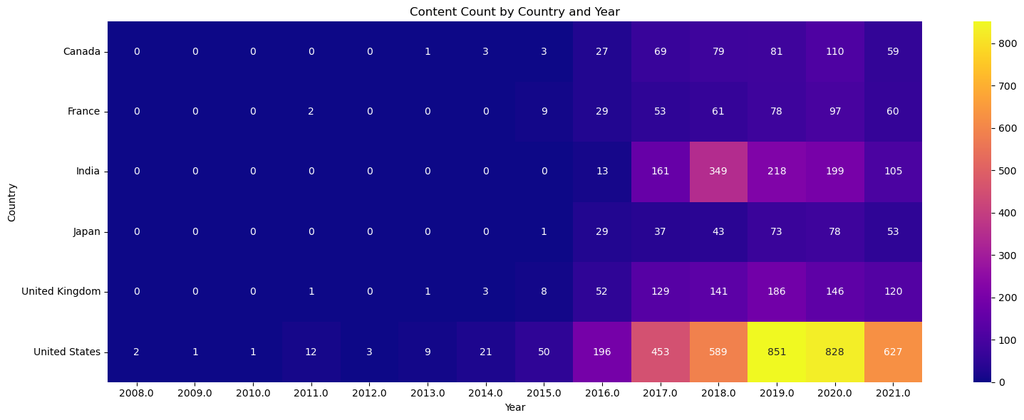

```python
# Explode countries and get year
df_exploded = df.dropna(subset=['country']).copy()
df_exploded['year_added'] = pd.to_datetime(df_exploded['date_added'], errors='coerce').dt.year
df_exploded = df_exploded.assign(country=df_exploded['country'].str.split(',')).explode('country')
df_exploded['country'] = df_exploded['country'].str.strip()

# Filter top 6 counties
top_countries = df_exploded['country'].value_counts().head(6).index
df_top = df_exploded[df_exploded['country'].isin(top_countries)]

# Create pivot table
heatmap_data = df_top.pivot_table(index='country', columns='year_added', aggfunc='size', fill_value=0)


# Plot heatmap
plt.figure(figsize=(16, 6))
sns.heatmap(heatmap_data, cmap='plasma', annot=True, fmt='d')
plt.title('Content Count by Country and Year')
plt.xlabel('Year')
plt.ylabel('Country')
plt.tight_layout()
plt.show()
```

**Interpretation** - Top content-producing countries like the US and India saw dramatic content growth starting from 2016. Some countries show sharp rises in specific years, revealing localized investment strategies.

### TV Shows vs Movies Share on Netflix:

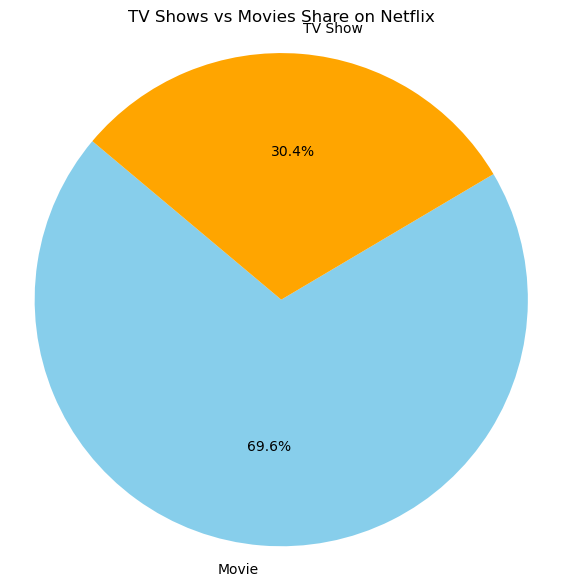

```python
# Count types
type_counts = df['type'].value_counts()

# Plot pie chart
plt.figure(figsize=(7,7))
plt.pie(type_counts, labels=type_counts.index, autopct='%1.1f%%', startangle=140, colors=['skyblue', 'orange'])
plt.title("TV Shows vs Movies Share on Netflix")
plt.axis('equal')
plt.show()
```

**Interpretation** - This pie chart reconfirms that Movies make up the majority (~70%) of Netflix's library, while TV Shows account for the remaining (~30%), indicating Netflix's inclination toward film-based content.

### Final Interpretation:

Netflix's content library is predominantly made up of movies (~70%), showing a clear preference for film-based content. A sharp rise in content additions began around 2016, with the United States and India leading in production volume. This reflects Netflix's aggressive global expansion and localized investment strategies during that period. Most content is modern (post-2000), clustered around common genres like dramas, comedies and international shows, and is targeted mainly at teens and adults. Overall, Netflix's data reveals a strategic focus on scalable, globally appealing, and diverse content offerings, tailored to modern viewer preferences.